# IODS course project

## Principal component analysis (PCA)

Principal component analysis (PCA) is a method to reduce the dimensionality of the data. This makes it easier to visualise and interpret while preserving the maximum amount of information. In order to do this, the technique transforms most of the variation in the data to fewer dimensions. These dimensions are then called principal components. Generally, the first two new dimensions are used to plot and then interpret the data.

In this case, the PCA is first done to the non-standardised data and then to the standardised version of the same data.

```r
pca_human <- prcomp(human)

s <- summary(pca_human)
s
```

```
## Importance of components:
##                              PC1      PC2   PC3   PC4   PC5   PC6    PC7    PC8
## Standard deviation     1.854e+04 185.5219 25.19 11.45 3.766 1.566 0.1912 0.1591
## Proportion of Variance 9.999e-01   0.0001  0.00  0.00 0.000 0.000 0.0000 0.0000
## Cumulative Proportion  9.999e-01   1.0000  1.00  1.00 1.000 1.000 1.0000 1.0000
```

```r
#pca_human

eigenvalues <- s$sdev^2
eigenvalues
```

```
## [1] 3.438860e+08 3.441836e+04 6.343853e+02 1.312035e+02 1.418457e+01
## [6] 2.452081e+00 3.655943e-02 2.531638e-02
```

```r
pca_pr <- round(1*s$importance[2, ], digits = 2)*100
# print out the percentages of variance
pca_pr
```

```
## PC1 PC2 PC3 PC4 PC5 PC6 PC7 PC8
## 100   0   0   0   0   0   0   0
```

The non-standardised data set produces quite interesting results: all variation in the data is assigned to the first principal component. Meaning there is only a single dimension found in the data.

[output not shown]

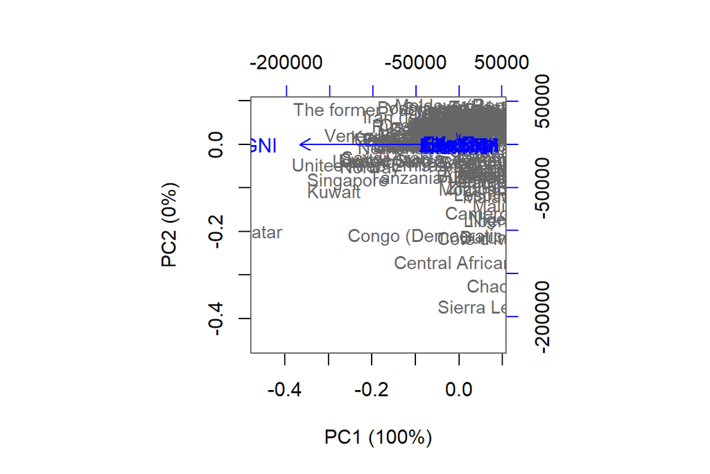

```r
#visualising the PCA results

#paste0(names(pca_pr), " (", pca_pr, "%)")

pc_lab <- paste0(names(pca_pr), " (", pca_pr, "%)")

# drawing a biplot
biplot(pca_human, cex = c(0.9, 1), col = c("grey40", "blue"), xlab = pc_lab[1], ylab = pc_lab[2])
```

The biplot has only one arrow, as the PCA did not manage to find more than one dimension (or principal component). Rstudio also notifies the user about this: “Warning: zero-length arrow is of indeterminate angle and so skipped”. The plot looks a bit funny, but probably standardising the data will help to produce more meaningful results.

## Principal component analysis (PCA) with a standardised dataset

```r
#standardising the data set
human_std <- scale(human)
summary(human_std)
```

```
##     Edu2.FM           Labo.FM           Edu.Exp           Life.Exp
##  Min.   :-2.8189   Min.   :-2.6247   Min.   :-2.7378   Min.   :-2.7188
##  1st Qu.:-0.5233   1st Qu.:-0.5484   1st Qu.:-0.6782   1st Qu.:-0.6425
##  Median : 0.3503   Median : 0.2316   Median : 0.1140   Median : 0.3056
##  Mean   : 0.0000   Mean   : 0.0000   Mean   : 0.0000   Mean   : 0.0000
##  3rd Qu.: 0.5958   3rd Qu.: 0.7350   3rd Qu.: 0.7126   3rd Qu.: 0.6717
##  Max.   : 2.6646   Max.   : 1.6632   Max.   : 2.4730   Max.   : 1.4218
##       GNI             Mat.Mor          Ado.Birth          Parli.F
##  Min.   :-0.9193   Min.   :-0.6992   Min.   :-1.1325   Min.   :-1.8203
##  1st Qu.:-0.7243   1st Qu.:-0.6496   1st Qu.:-0.8394   1st Qu.:-0.7409
##  Median :-0.3013   Median :-0.4726   Median :-0.3298   Median :-0.1403
##  Mean   : 0.0000   Mean   : 0.0000   Mean   : 0.0000   Mean   : 0.0000
##  3rd Qu.: 0.3712   3rd Qu.: 0.1932   3rd Qu.: 0.6030   3rd Qu.: 0.6127
##  Max.   : 5.6890   Max.   : 4.4899   Max.   : 3.8344   Max.   : 3.1850
```

```r
pca_human_std <- prcomp(human_std)
s <- summary(pca_human_std)
s
```

```
## Importance of components:
##                           PC1    PC2     PC3     PC4     PC5     PC6     PC7
## Standard deviation     2.0708 1.1397 0.87505 0.77886 0.66196 0.53631 0.45900
## Proportion of Variance 0.5361 0.1624 0.09571 0.07583 0.05477 0.03595 0.02634
## Cumulative Proportion  0.5361 0.6984 0.79413 0.86996 0.92473 0.96069 0.98702
##                            PC8
## Standard deviation     0.32224
## Proportion of Variance 0.01298
## Cumulative Proportion  1.00000
```

```r
#Eigenvectors
pca_human_std
```

```
## Standard deviations (1, .., p=8):
## [1] 2.0708380 1.1397204 0.8750485 0.7788630 0.6619563 0.5363061 0.4589994
## [8] 0.3222406
##
## Rotation (n x k) = (8 x 8):
##                   PC1         PC2         PC3         PC4        PC5
## Edu2.FM   -0.35664370  0.03796058 -0.24223089  0.62678110 -0.5983585
## Labo.FM    0.05457785  0.72432726 -0.58428770  0.06199424  0.2625067
## Edu.Exp   -0.42766720  0.13940571 -0.07340270 -0.07020294  0.1659678
## Life.Exp  -0.44372240 -0.02530473  0.10991305 -0.05834819  0.1628935
## GNI       -0.35048295  0.05060876 -0.20168779 -0.72727675 -0.4950306
## Mat.Mor    0.43697098  0.14508727 -0.12522539 -0.25170614 -0.1800657
## Ado.Birth  0.41126010  0.07708468  0.01968243  0.04986763 -0.4672068
## Parli.F   -0.08438558  0.65136866  0.72506309  0.01396293 -0.1523699
##                   PC6         PC7         PC8
## Edu2.FM    0.17713316  0.05773644  0.16459453
## Labo.FM   -0.03500707 -0.22729927 -0.07304568
## Edu.Exp   -0.38606919  0.77962966 -0.05415984
## Life.Exp  -0.42242796 -0.43406432  0.62737008
## GNI        0.11120305 -0.13711838 -0.16961173
## Mat.Mor    0.17370039  0.35380306  0.72193946
## Ado.Birth -0.76056557 -0.06897064 -0.14335186
## Parli.F    0.13749772  0.00568387 -0.02306476
```

```r
pca_pr <- round(1*s$importance[2, ], digits = 2)*100
# print out the percentages of variance
pca_pr
```

```
## PC1 PC2 PC3 PC4 PC5 PC6 PC7 PC8
##  54  16  10   8   5   4   3   1
```

This time the PCA seemed to work better: the variation is assigned to several principal components. The first component includes most of the variation: 54 %. The second component has an unmistakably smaller amount of variation: only 16 %.

```r
eigenvalues <- s$sdev^2
eigenvalues
```

```
## [1] 4.2883701 1.2989625 0.7657100 0.6066276 0.4381862 0.2876242 0.2106805
## [8] 0.1038390
```

Eigenvalues are used to determine the number of principal components. One rule of thumb recommends only using the principal components with eigenvalues that are greater than 1. In this case, the first two principal components fulfill this rule.

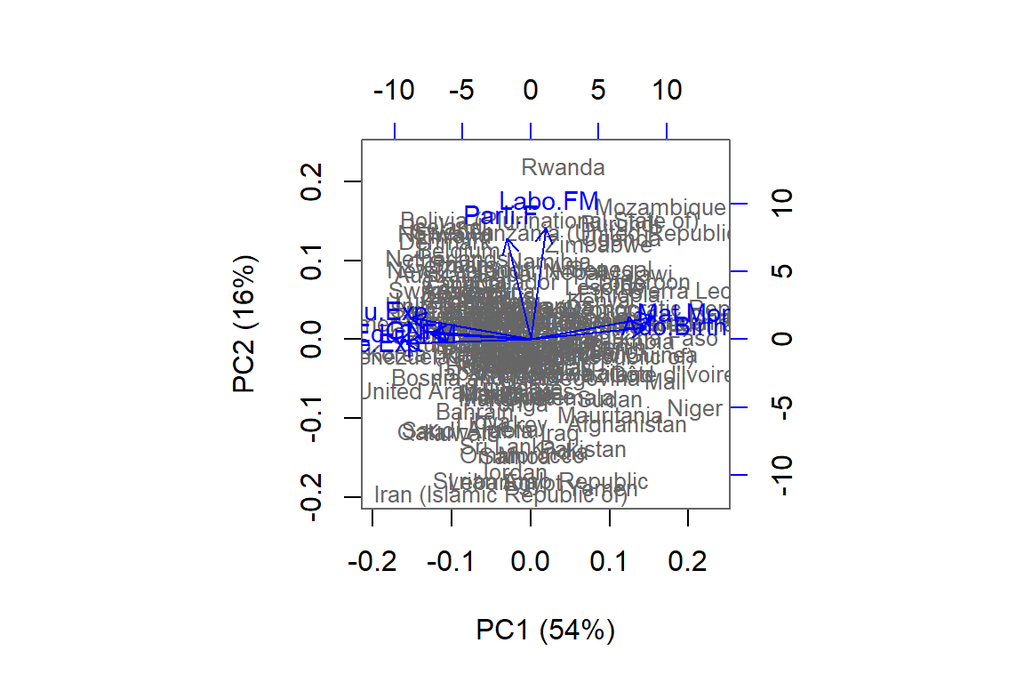

```r
#visualising the PCA results

#paste0(names(pca_pr), " (", pca_pr, "%)")

pc_lab <- paste0(names(pca_pr), " (", pca_pr, "%)")

# drawing a biplot
biplot(pca_human_std, cex = c(0.8, 0.9), col = c("grey40", "blue"), xlab = pc_lab[1], ylab = pc_lab[2])
```

Similarly, the biplot seems to be more sensible. The data points (=countries) are centered in the plot and all of the variables have their arrows visible.

However, the second analysis produces meaningful results. Maternal mortality and adolescent birth rate are positively associated with the first component. This can be seen in the biplot or from the eigenvectors. It seems that the first component deals with the health of the mother. The second component, on the other hand, is associated positively with the ratio of females and males in the workforce and the ratio of female representation in parliament. Therefore this component seems to be concerned with female participation in public life (as opposed to private life e.g. being a housewife etc.)

### Interpretations of the first two principal components

As mentioned above, the first principal component consists of maternal mortality and the adolescent birth rate which have a positive association with the component. Therefore, I would say that the component deals with the health of mothers. Possibly even ill health as the association is positive and both variables seem to concern negative effects (death and motherhood at a very young age).

The second principal component has also to do with women. This time the component has a positive correlation with the ratio of females vs, males in the workforce and the ratio of female representation in parliament. Hence, the second component seems to represent women’s attendance in public life: it has to do with women in the working life and the public sphere instead of private life (= at home).